# Getting started with imager

Simon Barthelmé

2025-03-25

**imager** contains a large array of functions for working with image data, with most of these functions coming from the [CImg library](http://www.cimg.eu/) by David Tschumperlé. This vignette is just a short tutorial, you’ll find more information and examples on the website. Each function in the package is documented and comes with examples, so have a look at package documentation as well.

# 1 Plotting and loading images

**imager** comes with an example picture of boats. Let’s have a look:

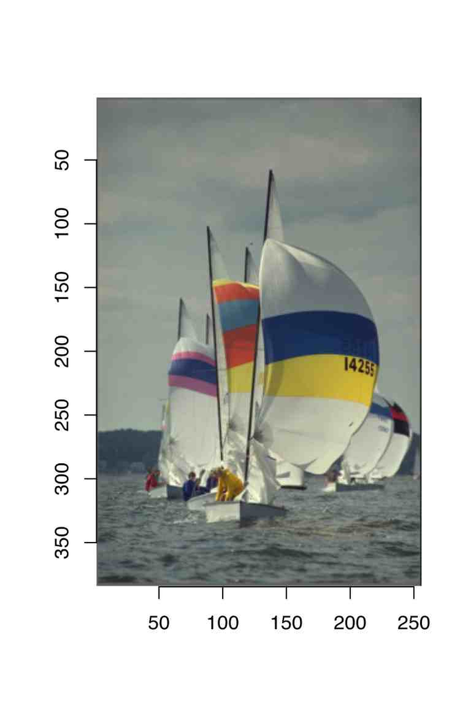

```r
library(imager)
plot(boats)
```

Note the y axis running downwards: the origin is at the top-left corner, which is the traditional coordinate system for images. **imager** uses this coordinate system consistently. Image data has class “cimg”:

```r
class(boats)
```

```
[1] "cimg"         "imager_array" "numeric"
```

and we can get some basic info by typing:

```r
boats
```

```
Image. Width: 256 pix Height: 384 pix Depth: 1 Colour channels: 3
```

Width and height should be self-explanatory. Depth is how many frames the image has: if depth > 1 then the image is actually a video. Boats has three colour channels, the usual RGB. A grayscale version of boats would have only one:

```r
grayscale(boats)
```

```
Image. Width: 256 pix Height: 384 pix Depth: 1 Colour channels: 1
```

An object of class cimg is actually just a thin interface over a regular 4D array:

```r
dim(boats)
```

```
[1] 256 384   1   3
```

We’ll see below how images are stored exactly. For most intents and purposes, they behave like regular arrays, meaning the usual arithmetic operations work:

```r
log(boats)+3*sqrt(boats)
```

```
Image. Width: 256 pix Height: 384 pix Depth: 1 Colour channels: 3
```

```r
mean(boats)
```

```
[1] 0.5089061
```

```r
sd(boats)
```

```
[1] 0.144797
```

Now you might wonder why the following two images look exactly the same:

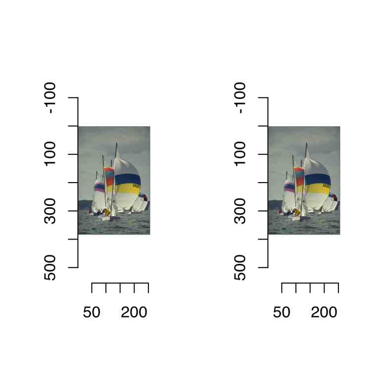

```r
layout(t(1:2))
plot(boats)
plot(boats/2)
```

That’s because the `plot` function automatically rescales the image data so that the whole range of colour values is used. There are two reasons why that’s the default behaviour:

1. There’s no agreed-upon standard for how RGB values should be scaled. Some software, like CImg, uses a range of 0-255 (dark to light), other, like R’s `rgb` function, uses a 0-1 range.
2. Often it’s just more convenient to work with a zero-mean image, which means having negative values.

If you don’t want **imager** to rescale the colours automatically, set rescale to FALSE, but now **imager** will want values that are in the $[0,1]$ range.

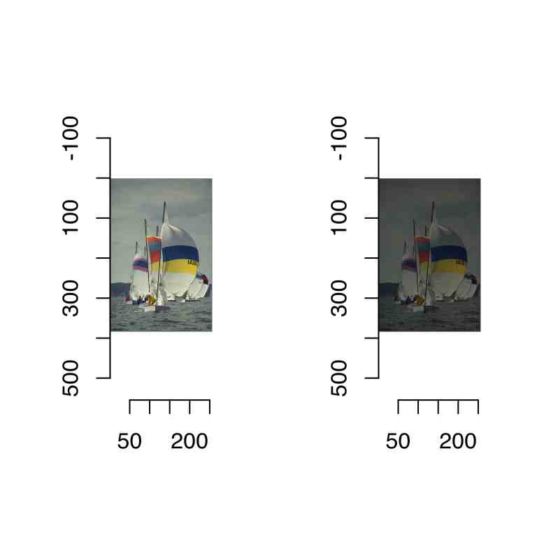

```r
layout(t(1:2))
plot(boats,rescale=FALSE)
plot(boats/2,rescale=FALSE)
```

If you’d like tighter control over how **imager** converts pixel values into colours, you can specify a colour scale. R likes its colours defined as hex codes, like so:

```r
rgb(0,1,0)
```

```
[1] "#00FF00"
```

The function `rgb` is a colour scale, i.e., it takes pixel values and returns colours. We can define an alternative colour scale that swaps the red and green values:

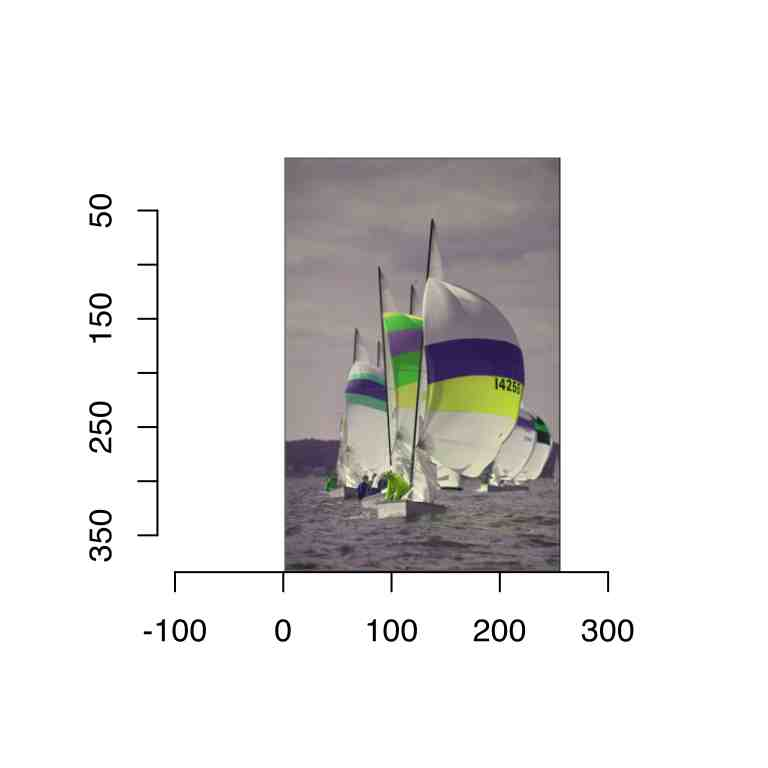

```r
cscale <- function(r,g,b) rgb(g,r,b)
plot(boats,colourscale=cscale,rescale=FALSE)
```

In grayscale images pixels have only one value, so that the colour map is simpler: it takes a single value and returns a colour. In the next example we convert the image to grayscale

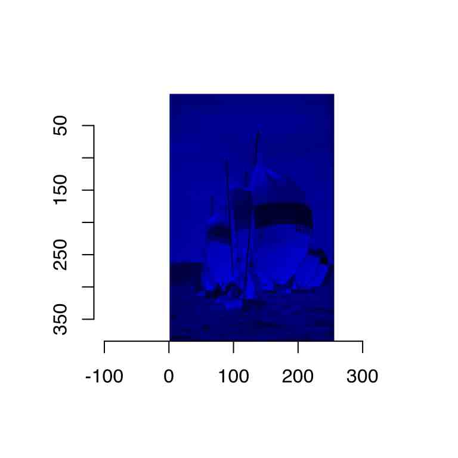

```r
#Map grayscale values to blue
cscale <- function(v) rgb(0,0,v)
grayscale(boats) %>% plot(colourscale=cscale,rescale=FALSE)
```

The scales package has a few handy functions for creating colour scales, for example by interpolating a gradient:

```r
cscale <- scales::gradient_n_pal(c("red","purple","lightblue"),c(0,.5,1))
#cscale is now a function returning colour codes
cscale(0)
```

```
[1] "#FF0000"
```

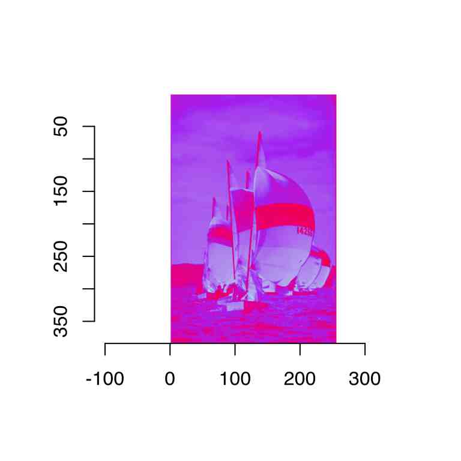

```r
grayscale(boats) %>% plot(colourscale=cscale,rescale=FALSE)
```

See the documentation for `plot.cimg` and `as.raster.cimg` for more information and examples.

The next thing you’ll probably want to be doing is to load an image, which can be done using load.image. **imager** ships with another example image, which is stored somewhere in your R library. We find out where using `system.file`

```r
fpath <- system.file('extdata/parrots.png',package='imager')
```

We’re now ready to load the image:

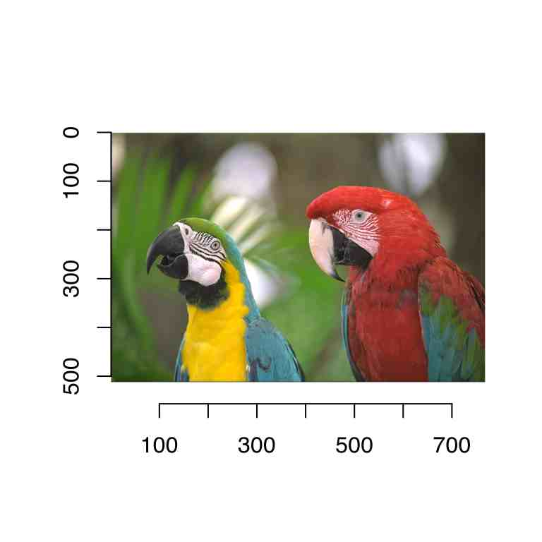

```r
parrots <- load.image(fpath)
plot(parrots)
```

**imager** supports JPEG, PNG, TIFF and BMP natively - for other formats you’ll need to install [ImageMagick](http://www.imagemagick.org/script/index.php).

# 2 Example 1: Histogram equalisation

Histogram equalisation is a textbook example of a contrast-enhancing filter. It’s also a good topic for an introduction to what you can do with **imager**.

Image histograms are just histogram of pixel values, which are of course pretty easy to obtain in R:

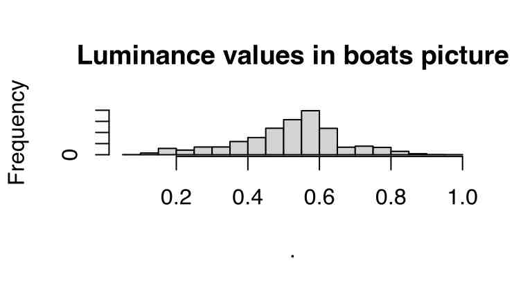

```r
grayscale(boats) %>% hist(main="Luminance values in boats picture")
```

Since images are stored essentially as arrays, here we’re just using R’s regular hist function, which treats our array as a vector of values. If we wanted to look only at the red channel, we could use:

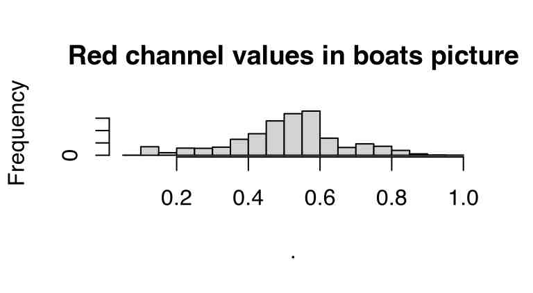

```r
R(boats) %>% hist(main="Red channel values in boats picture")
```

```r
#Equivalently:
#channel(boats,1) %>% hist(main="Red channel values in boats picture")
```

Another approach is to turn the image into a `data.frame`, and use `ggplot` to view all channels at once:

```r
library(ggplot2)
library(dplyr)
bdf <- as.data.frame(boats)
head(bdf,3)
```

```
  x y cc     value
1 1 1  1 0.3882353
2 2 1  1 0.3858633
3 3 1  1 0.3849406
```

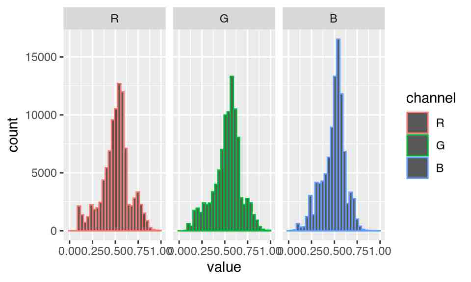

```r
bdf <- mutate(bdf,channel=factor(cc,labels=c('R','G','B')))
ggplot(bdf,aes(value,col=channel))+geom_histogram(bins=30)+facet_wrap(~ channel)
```

What we immediately see from these histograms is that the middle values are in a sense over-used: there’s very few pixels with high or low values. Histogram equalisation solves the problem by making histograms flat: each pixel’s value is replaced by its *rank*, which is equivalent to running the data through their empirical cdf.

As an illustration of what this does, see the following example:

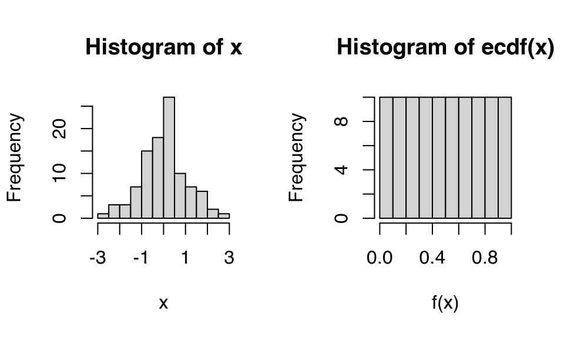

```r
x <- rnorm(100)
layout(t(1:2))
hist(x,main="Histogram of x")
f <- ecdf(x)
hist(f(x),main="Histogram of ecdf(x)")
```

We can apply it directly to images as follows:

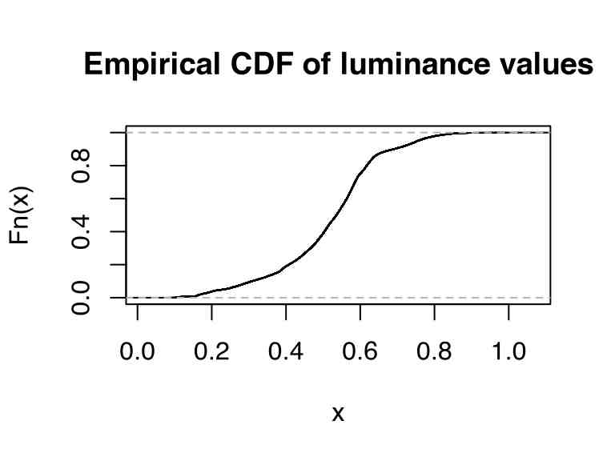

```r
boats.g <- grayscale(boats)
f <- ecdf(boats.g)
plot(f,main="Empirical CDF of luminance values")
```

Again we’re using a standard R function (`ecdf`), which returns another function corresponding to the ECDF of luminance values in boats.g.

If we run the pixel data back through `f` we get a flat histogram:

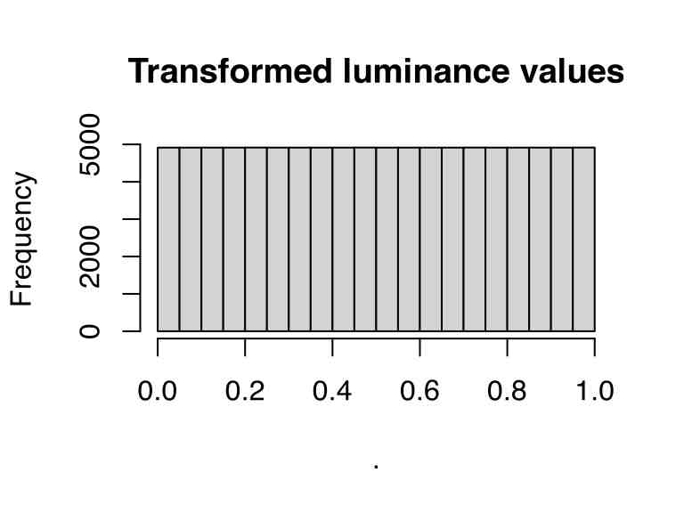

```r
f(boats.g) %>% hist(main="Transformed luminance values")
```

Now the only problem is that ecdf is base R, and unaware of our cimg objects. The function `f` took an image and returned a vector:

```r
f(boats.g) %>% str
```

```
 num [1:98304] 0.171 0.165 0.163 0.164 0.165 ...
```

If we wish to get an image back we can just use as.cimg:

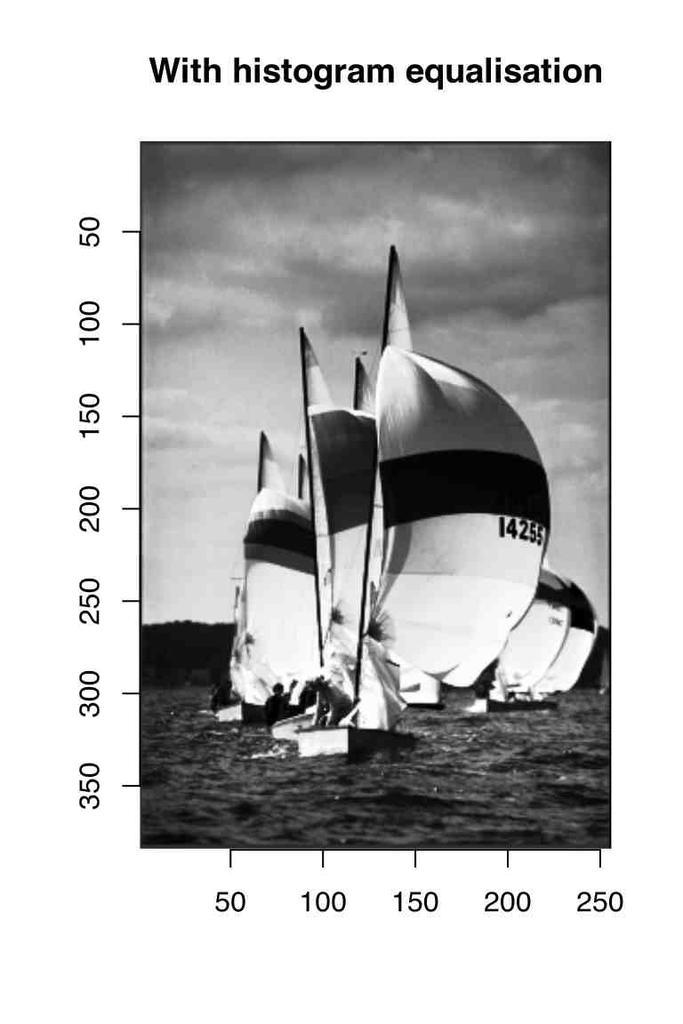

```r
f(boats.g) %>% as.cimg(dim=dim(boats.g)) %>% plot(main="With histogram equalisation")
```

So far we’ve run this on a grayscale image. If we want to do this on RGB data, we need to run the equalisation separately in each channel. **imager** enables this using its split-apply-combine tricks:

```r
#Hist. equalisation for grayscale
hist.eq <- function(im) as.cimg(ecdf(im)(im),dim=dim(im))

#Split across colour channels,
cn <- imsplit(boats,"c")
cn #we now have a list of images
```

```
Image list of size 3
```

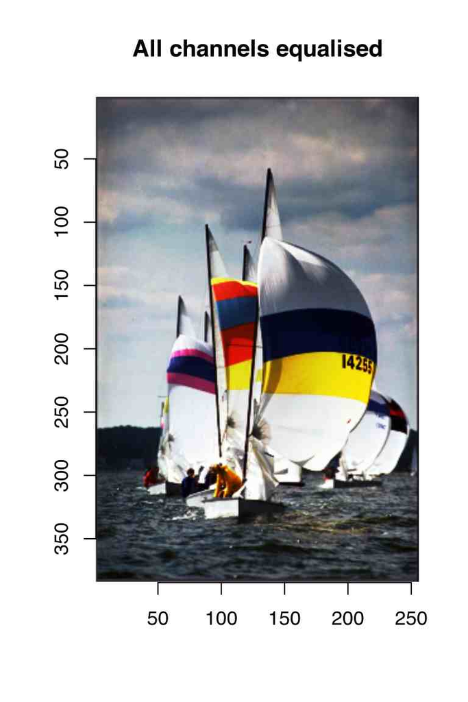

```r
cn.eq <- map_il(cn,hist.eq) #run hist.eq on each
imappend(cn.eq,"c") %>% plot(main="All channels equalised") #recombine and plot
```

The map_il function is a variant of lapply inspired by the [purrr](https://purrr.tidyverse.org/) package. It applies a function to each element of a list and returns an image list. You can use purrr together with image for all kinds of neat tricks, e.g.:

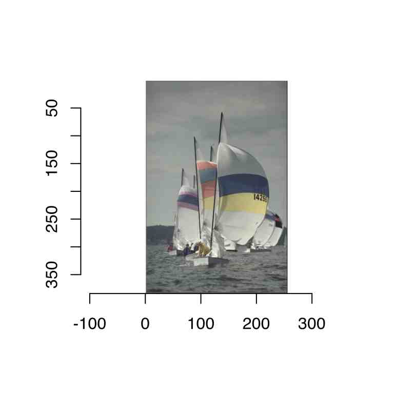

```r
library(purrr)
#Convert to HSV, reduce saturation, convert back
RGBtoHSV(boats) %>% imsplit("c") %>%
    modify_at(2,~ . / 2) %>% imappend("c") %>%
    HSVtoRGB %>% plot(rescale=FALSE)
```

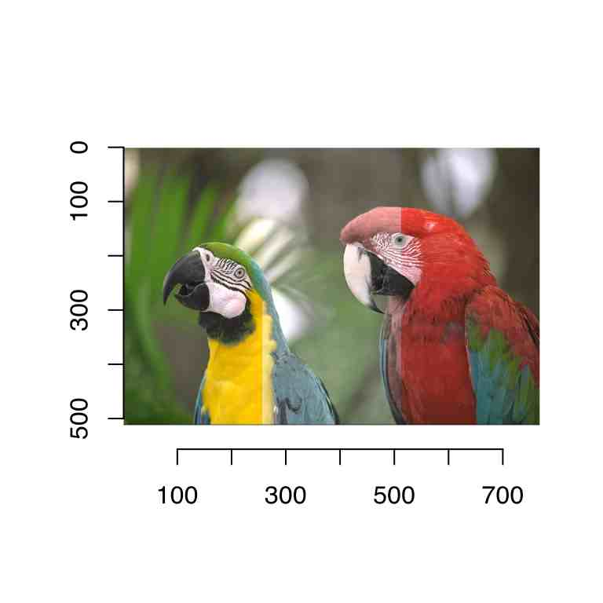

```r
#Turn into a function
desat <- function(im) RGBtoHSV(im) %>% imsplit("c") %>%
    modify_at(2,~ . / 2) %>% imappend("c") %>%
    HSVtoRGB

#Split image into 3 blocks, reduce saturation in middle block, recombine
im <- load.example("parrots")
imsplit(im,"x",3) %>% modify_at(2,desat) %>%
    imappend("x") %>% plot(rescale=FALSE)
```

# 3 Example 2: Edge detection

Edge detection relies on image gradients, which **imager** returns via:

```r
gr <- imgradient(boats.g,"xy")
gr
```

```
Image list of size 2
```

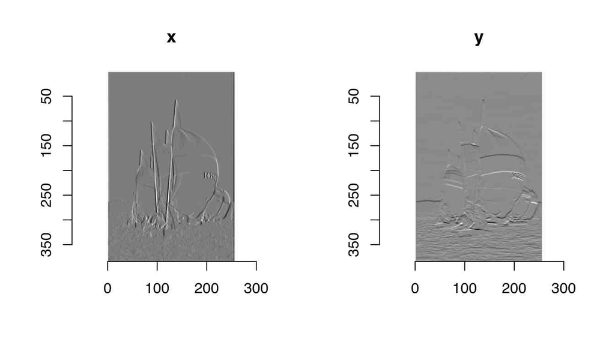

```r
plot(gr,layout="row")
```

The object “gr” is an image list, with two components, one for the gradient along $x$, the other for the gradient along $y$. “gr” is an object with class “imlist”, which is just a list of images but comes with a few convenience functions (for example, a plotting function as used above).

To be more specific, noting $I(x,y)$ the image intensity at location $x,y$, what **imager** returns is an approximation of:
$$\frac{\partial}{\partial x}I$$
in the first panel and:
$$\frac{\partial}{\partial y}I$$
in the second.

The magnitude of the gradients thus tell us how fast the image changes around a certain point. Image edges correspond to abrubt changes in the image, and so it’s reasonable to estimate their location based on the norm of the gradient
$$\sqrt{\left(\frac{\partial}{\partial
x}I\right)^{2}+\left(\frac{\partial}{\partial y}I\right)^{2}}$$

In **imager**:

[figure not shown]

```r
dx <- imgradient(boats.g,"x")
dy <- imgradient(boats.g,"y")
grad.mag <- sqrt(dx^2+dy^2)
plot(grad.mag,main="Gradient magnitude")
```

Here’s a handy shortcut:

[figure not shown]

```r
imgradient(boats.g,"xy") %>% enorm %>% plot(main="Gradient magnitude (again)")
```

The first function returns a list of images:

```r
l <- imgradient(boats.g,"xy")
str(l)
```

```
List of 2
 $ x: 'cimg' num [1:256, 1:384, 1, 1] 0.002885 0.002968 -0.000495 -0.000315 0.000121 ...
 $ y: 'cimg' num [1:256, 1:384, 1, 1] 0.00493 0.01123 0.01534 0.01472 0.0139 ...
 - attr(*, "class")= chr [1:2] "imlist" "list"
```

And the second takes a list of images and computes the Euclidean norm pixel-wise, i.e., the i-th pixel of the output equals:

$$u_i = \sqrt( \sum_j x_{ij}^2)$$

where $x_ij$ is the value of pixel $i$ in the $j-th$ element of the list.

`enorm` is an example of a “reduction” function. They’re useful for combining pixel values over several images. We’ll see another example below when we look at blob detection.

# 4 imager and ggplot2

To plot your image data using **ggplot2**, use `as.data.frame` and `geom_raster`:

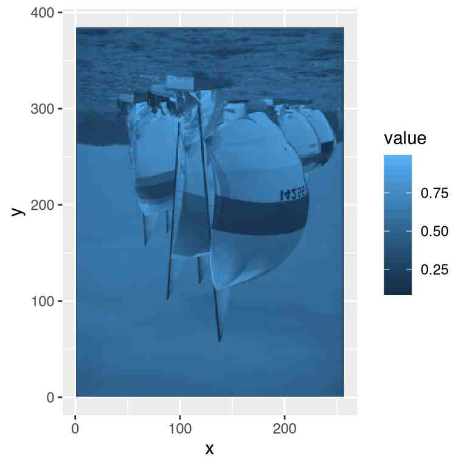

```r
df <- grayscale(boats) %>% as.data.frame
p <- ggplot(df,aes(x,y))+geom_raster(aes(fill=value))
p
```

We’re not quite there, mainly because our y axis is reversed. Here’s a fix:

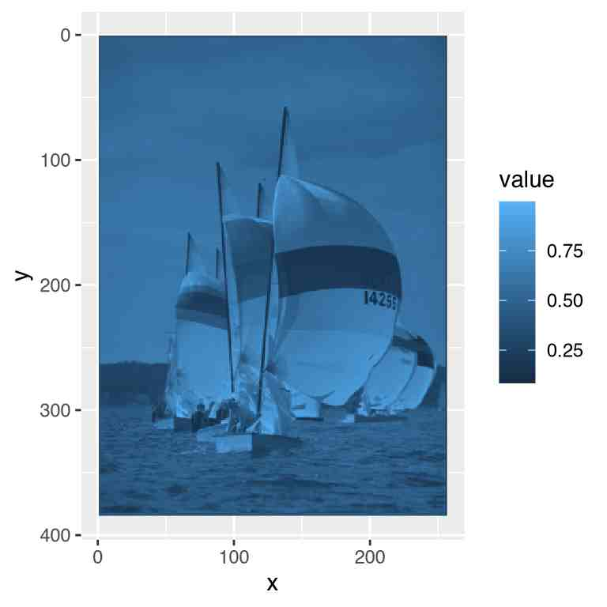

```r
p + scale_y_continuous(trans=scales::reverse_trans())
```

The grey margin around the plot should be eliminated as well:

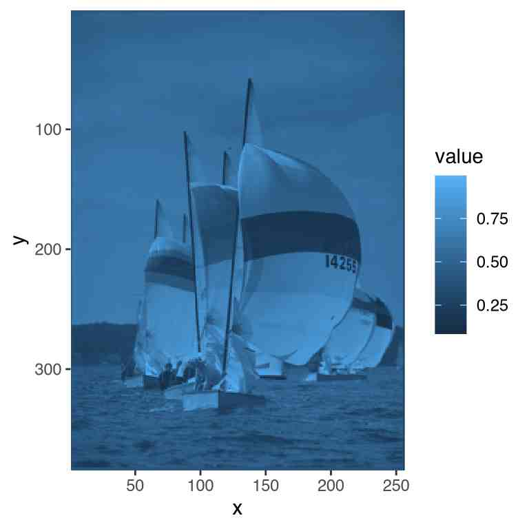

```r
p <- p+scale_x_continuous(expand=c(0,0))+scale_y_continuous(expand=c(0,0),trans=scales::reverse_trans())
p
```

Finally, `ggplot` has a blue colour scale by default, but we might want to keep our original grays:

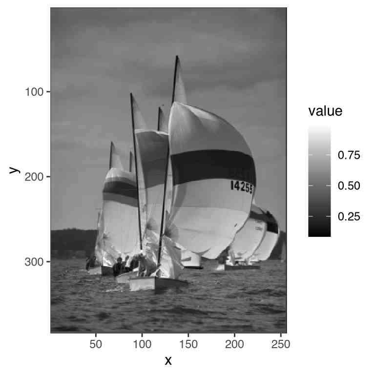

```r
p+scale_fill_gradient(low="black",high="white")
```

Colour images are a bit trickier. We could plot each channel separately:

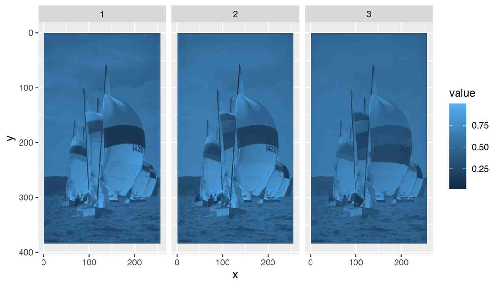

```r
df <- as.data.frame(boats)
p <- ggplot(df,aes(x,y))+geom_raster(aes(fill=value))+facet_wrap(~ cc)
p+scale_y_reverse()
```

Plotting channels separately may be useful on occasion, but usually we’d want the original colours. We can tell as.data.frame to return a “wide” format:

```r
as.data.frame(boats,wide="c") %>% head
```

```
  x y       c.1       c.2       c.3
1 1 1 0.3882353 0.3882353 0.3882353
2 2 1 0.3858633 0.3858633 0.3858633
3 3 1 0.3849406 0.3849406 0.3849406
4 4 1 0.3852481 0.3852481 0.3852481
5 5 1 0.3860388 0.3860388 0.3860388
6 6 1 0.3855557 0.3855557 0.3855557
```

The three colour channels are now stacked along columns, which lets us do the following:

```r
df <- as.data.frame(boats,wide="c") %>% mutate(rgb.val=rgb(c.1,c.2,c.3))
head(df,3)
```

```
  x y       c.1       c.2       c.3 rgb.val
1 1 1 0.3882353 0.3882353 0.3882353 #636363
2 2 1 0.3858633 0.3858633 0.3858633 #626262
3 3 1 0.3849406 0.3849406 0.3849406 #626262
```

We can now plot our image using `ggplot`’s identity scale:

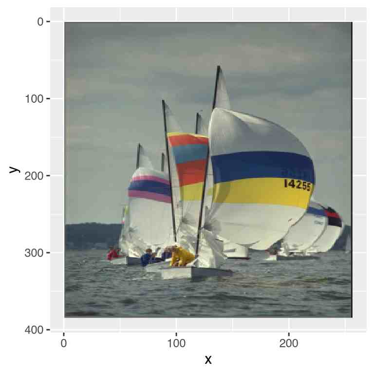

```r
p <- ggplot(df,aes(x,y))+geom_raster(aes(fill=rgb.val))+scale_fill_identity()
p+scale_y_reverse()
```

We’ll see more interesting uses for **ggplot2** later.

# 5 Blob detection/extraction of local maxima, denoising, scale-space

Our goal will be to find the coordinates of the galaxies in this picture (I took the idea from the documentation for [scikit-image](https://scikit-image.org/))

[figure not shown]

```r
hub <- load.example("hubble") %>% grayscale
plot(hub,main="Hubble Deep Field")
```

Before we can work with the real image we’ll try synthetic data. Here’s how to generate an image with a few randomly placed blobs:

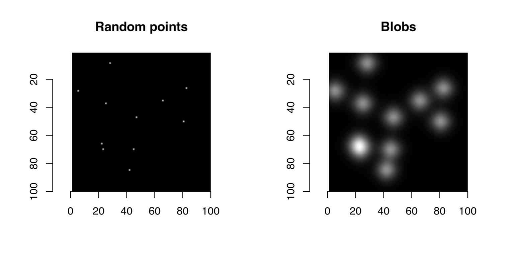

```r
layout(t(1:2))
set.seed(2)
points <- rbinom(100*100,1,.001) %>% as.cimg
blobs <- isoblur(points,5)
plot(points,main="Random points")
plot(blobs,main="Blobs")
```

blobs are obtained from random points convolved with a blur kernel of size 5 pixels. Note the shortcut in:

```r
rbinom(100*100,1,.001) %>% as.cimg
```

```
Warning in as.cimg.vector(obj, ...): Guessing input is a square 2D image
```

```
Image. Width: 100 pix Height: 100 pix Depth: 1 Colour channels: 1
```

where a vector of length 100^2 is turned into an image of dimension 100x100. That’s just a guess on **imager**’s part and it’s reported with a warning (we could be dealing with an image of dimension 10x1000, for instance). To get rid of the warning you have to be explicit about the dimensions you want:

```r
rbinom(100*100,1,.001) %>% as.cimg(x=100,y=100)
```

```
Image. Width: 100 pix Height: 100 pix Depth: 1 Colour channels: 1
```

Suppose our task is to find the location of the center of the blobs. There are several way of doing that, but one that’s convenient is to go through image hessians. Blobs are local maxima in the image, and local maxima are usually associated with a hessian matrix that’s positive definite (the well-known second-order optimality condition). A matrix that’s positive definite has positive determinant, which we can compute via:

$$\mathrm{det}(H) = I_{xx} \times I_{yy}
- I_{xy}^2$$

where $I_{xx}$ is the second derivative of the image along x, etc. See wikipedia on [blob detection](https://en.wikipedia.org/wiki/Blob_detection) for more.

In **imager** we can use:

```r
imhessian(blobs)
```

```
Image list of size 3
```

to get the derivatives we need, and:

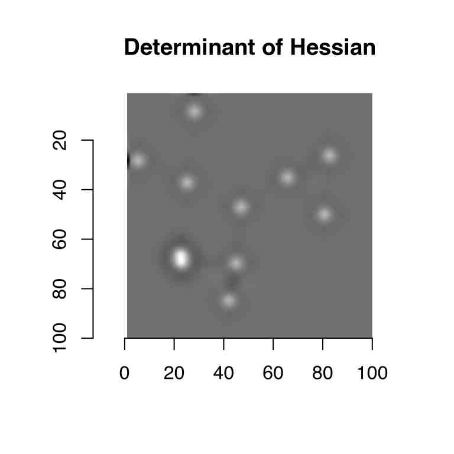

```r
Hdet <- with(imhessian(blobs),(xx*yy - xy^2))
plot(Hdet,main="Determinant of Hessian")
```

To get only the pixels with the highest values, we threshold the image:

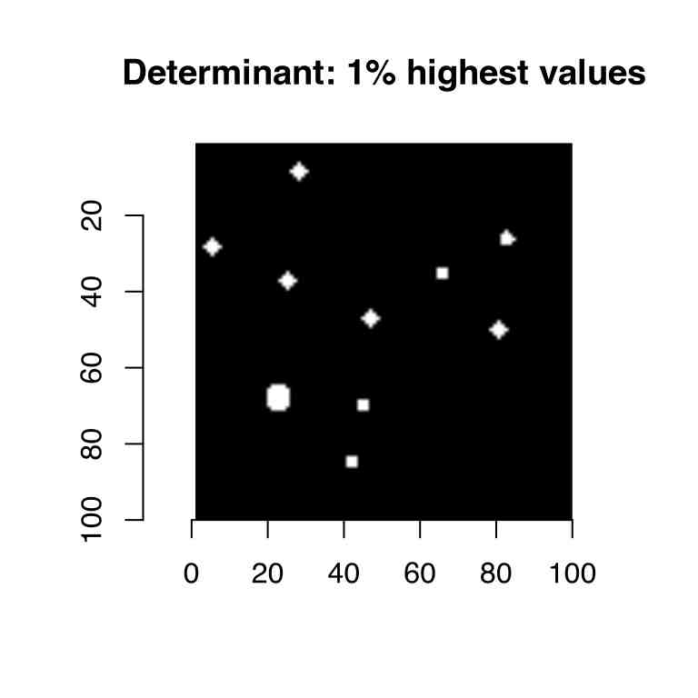

```r
threshold(Hdet,"99%") %>% plot(main="Determinant: 1% highest values")
```

The thresholded image now contains discrete image regions, and if we can compute the center of these regions we’ll have our locations. The first step is to label these regions:

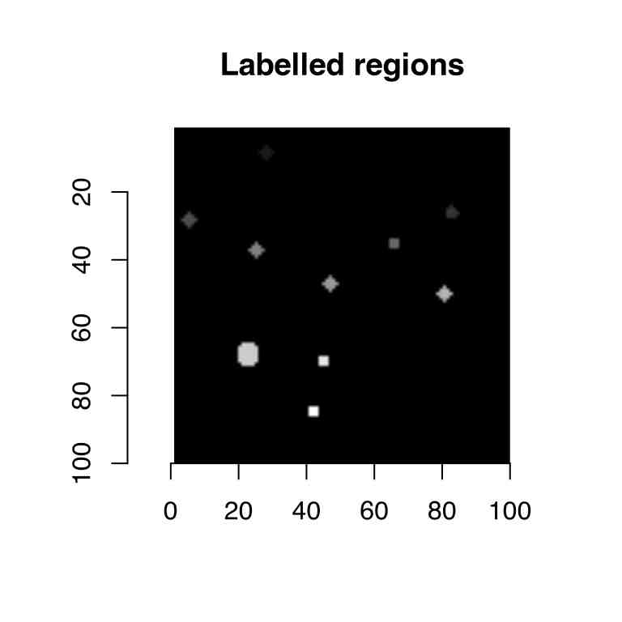

```r
lab <- threshold(Hdet,"99%") %>% label
plot(lab,main="Labelled regions")
```

label is a utility that fills each white region with a unique pixel value (the background stays at 0). We can extract the labelled regions in the form of a `data.frame`:

```r
df <- as.data.frame(lab) %>% subset(value>0)
head(df,3)
```

```
     x y value
528 28 6     1
627 27 7     1
628 28 7     1
```

```r
unique(df$value) #10 regions
```

```
 [1]  1  2  3  4  5  6  7  8  9 10
```

And now all we need to do is to split the data.frame into regions, and compute the mean coordinate values in each. Here’s a solution using **dplyr**:

```r
centers <- dplyr::group_by(df,value) %>% dplyr::summarise(mx=mean(x),my=mean(y))
```

As an exercise you can try extracting other summary values for the regions (area, for example, or aspect ratio).